# Coding Like a Researcher

In my experience, many students start coding near the end of a research project. For example, they might start after they already have a candidate algorithm and performance guarantee. The goal of the code is just to benchmark their algirthm against some other methods.

Compare this to the scientific method

1. Observe to generate a question
2. Form a conjecture based on preliminary data
3. Design and execute an experiment to test the conjecture
4. Analyze the data
5. Draw conclusions and repeat as necessary.

**For those of us in Data Science, which steps should involve coding?**

The purpose of this session is to see how to use software, plots, simulation, and Mathemaica in conjunction with heuristic thinking to first develop conjectures, and then to guide a proof. We do this with a couple of toy examples that have come up in my research.

### Task 1: Warm-Up

Suppose $N \sim \text{Pois}(\lambda)$.

- Provide the best upper bound you can on $\mathbb E[ 1/(N+1) ]$.
- Provide a high-probability bound on $1/(N+1)$.

**Developing Intuition** The first expectation is pretty straightforward to evaluate directly and is at most $1/\lambda$. You should do this carefully before moving forward.

For the second part, we could use standard machinery (like the Chernoff bound), but the resulting bound is a bit ugly and difficult to manipulate. I needed this result as part of a much larger proof, so a clean simple bound (even if it was looser) was important. (In general, you don't always need the tightest bound on a quantity, just a tight enough bound to get the job done.) So let's think a bit more broadly.

First, the random variable is always bounded by $1$. This bound is loose however when $\lambda \rightarrow \infty$. So our effort should be on improving the bound for large $\lambda$. Intuition suggests that $N = \lambda + O_p(\sqrt{\lambda})$ as $\lambda \rightarrow \infty$, and thus, \begin{align} \frac{1}{N+1} \approx \frac{1}{1 + \lambda + O_p(\sqrt{\lambda})} \approx \frac{1}{\lambda + 1} \cdot \frac{1}{1 + O_p\left( \frac{\sqrt{\lambda}}{\lambda + 1} \right) } \approx \frac{1}{\lambda + 1} \left( 1 + O_p\left( \frac{\sqrt{\lambda}}{\lambda + 1} \right) \right) \end{align}

So we might conjecture that $\frac{\lambda}{N+1} \rightarrow_p 1$ as $\lambda \rightarrow \infty$. How can we turn this conjecture about the asymptotics into a bound? Let's try calculating the $1-\epsilon$ quantile:

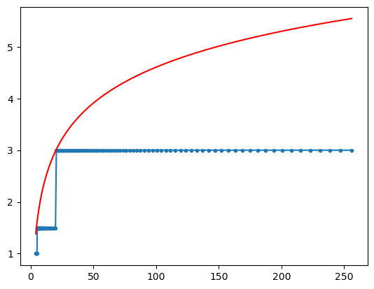

```
1-element Array{PyCall.PyObject,1}:
 PyObject <matplotlib.lines.Line2D object at 0x7f8a18294130>
```

```julia
function eps_quantile(lambda, epsilon)
    dist = Distributions.Poisson(lambda)
    q = quantile(dist, epsilon)
    return lambda/(q + 1)
end
lam = 3
eps_grid = 2 .^collect(-2:-.05:-8)
ts = map(eps -> eps_quantile(lam, eps), eps_grid)
plot(1 ./eps_grid, ts, ".-")
plot(1 ./eps_grid, log.(1 ./eps_grid), "red")
```

Play with the above plot for different values of $\lambda$. You should be able to convince yourself that the quantile is (much) less than $O(\log(1/\epsilon))$. This then seems like a good conjecture to try and prove. Given we have tails that look like $\log(1/\epsilon)$, one strategy might be to try use Markov's inequality with an exponential, i.e., \begin{align} \mathbb P\left( \frac{\theta \lambda}{N+1} > \log(1/\epsilon) \right) & \leq \epsilon \mathbb E\left[ \exp(\frac{\theta \lambda}{N+1})\right] \end{align}

Now let's try to compute this expectation to figure out a good value of $\theta$. First, let's look at some simulations.

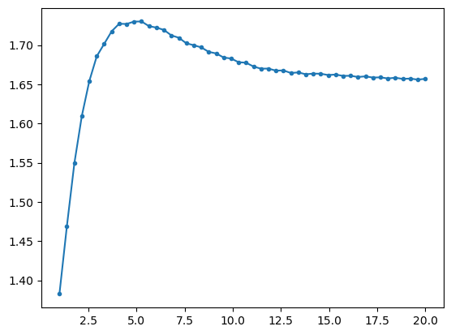

```
1-element Array{PyCall.PyObject,1}:
 PyObject <matplotlib.lines.Line2D object at 0x7f8a2966d850>
```

```julia
function e_expon(lambda, theta)
    dist = Distributions.Poisson(lambda)

    #Let's only compute terms within 3 stdevs of the mean... should cover most of the masss
    lb = floor(Int, lambda - 3 * sqrt(lambda))
    lb = max(0, lb)
    ub = floor(Int, lambda + 3 * sqrt(lambda))

    out = 0.
    for i in lb:ub
        out += exp(theta * lambda/ (i + 1)) * pdf(dist, i)
    end

    return out
end

lam_grid = range(1, 20, length=50)
out = map(lam -> e_expon(lam, 0.5), lam_grid)
plot(lam_grid, out, ".-")
```

Note, I did some "quick and dirty" things to get the code above to run reasonably fast. Since we're just tryign to generate a good conjecture, these sorts of tricks are usually a good idea, just make sure you don't confuse yourself later.

So it seems when $\theta = 0.5$, this expectation is at most $2$. Now we have a concrete conjectuer to prove:

- Prove that $\mathbb E\left[ \exp\left( \frac{\lambda}{2(N+1)} \right) \right] \leq 2$.

I leave the details to you, but it can be attacked by simply writing out the expectation carefully and using a trick similar to the one you did for $\mathbb E[1/(N+1)]$.

Putting it all together, if we bound the above expecation, we will have proven that with probability at least $1-\epsilon$, \begin{align} \frac{1}{N+1} \leq \frac{2 \log(1/\epsilon)}{\lambda} \end{align}

Again, this bound is definitely weaker than what you would get with the Chernoff technique. But it does have a very simple dependence, and roughly the right scaling in $\lambda$ for a fixed $\epsilon$. The tail dependence on $\epsilon$ could be improved, for what I needed in my proof, this was good enough.

### Task 2:

Your turn. Apply a similar logic to the one above to develop a nice high probability upper bound on $\frac{\log(N+1)}{N+1}$. To get you started, the following graph might be helpful

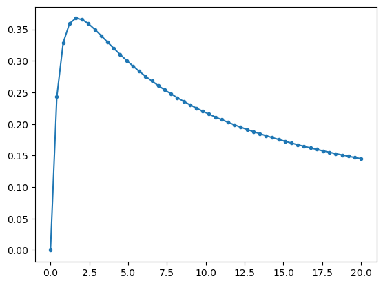

```
1-element Array{PyCall.PyObject,1}:
 PyObject <matplotlib.lines.Line2D object at 0x7f89fb7c3820>
```

```julia
n_grid = range(0, 20, length=50)
plot(n_grid, log.(n_grid .+ 1) ./ (n_grid .+ 1), ".-")
```

Probably worth noting that the graph has a finite maximum, and it's monotonically decreasing after that maximum. How can you leverage this fact to develop the requisite upper bound?

### Task 3:

This one is a bit more interesting.

Let $\Phi(\lambda) \in \mathbb R^p$ be a vector-valued function for $\lambda \in [-1, 1]$ and let $\Phi_i(\lambda)$ be the $i^\text{th}$ Legendre Polynomial (w.r.t. $[-1, 1]$).

With my coauthors, we developed an algorithm whose complexity scales like $\frac{C}{c}$ where \begin{align} C = \sup_{\lambda \in [-1, 1]} \sigma_{\max} \left( \Phi(\lambda) \Phi(\lambda)^T \right) \\ c = \sigma_{\min}\left( \mathbb E_{\tilde \lambda \sim \text{Unif}[-1, 1]}\left[\Phi(\lambda) \Phi(\lambda)^T\right] \right) \end{align}

How does the fraction $C/c$ scale as $p \rightarrow \infty$?

This problem seems a lot harder than it actually is. Let's start thinking about little c. The Legendre polynomials are an orthonormal basis. So the matrix $\mathbb E_{\tilde \lambda \sim \text{Unif}[-1, 1]}\left[\Phi(\lambda) \Phi(\lambda)^T\right]$ is actually the identity! So it $c = 1$.

The real work is in evaluating $C$. You should write some code to evaluate this for different values of $p$. Some things to ask yourself:

- Can you plot $C$ vs. $p$?
- What value(s) of $\lambda$ achieve the supremum?
- What's the corresponding eigenvector for the maximal eigenvalue?

  Once you investigate those questions numerically, it should be pretty clear how to craft a proof that $C/c = O(p)$ (in fact, I believe, $C/c = p$). Once you do that, you can look back at your proof and ask:

  *What was actually special about the Legendre Polynomials? Can I generalize this result to other basis functions?*

  I leave the details to you!